# Analisis Data Film IMDb

# Insight dan Manfaat

Dari Visualisasi plot yang kami sudah buat didapatkan insight:

- Umumnya seorang sutradara hanya bekerja bersama dengan seorang aktor sebanyak satu kali, dan sangat jarang lebih dari satu kali.

# Penggalian Insight Baru

Dari analisis yang telah dilakukan sebelumnya dan dari insight yang didapat, kami berusaha untuk menggali data lebih dalam dan mencoba untuk melihat bagaimana hubungan antara seringnya seorang sutradara dan aktor bekerja bersama dan pendapatan yang dihasilkan.

Untuk itu diperlukan tabel dengan bentuk sebagai berikut:

- DataActorDirector(Director, Actor, CountFilm, MeanRev)

Keterangan:

- - Director : Sutradara dari film
  - Actor : Aktor film
  - CountFilm : Jumlah Film yang disutradarai dan dimainkan
  - MeanRev : Rata-rata pendapatan dari film

# Penyiapan Data

Dari dataframe yang setiap baris di kolom Actor-nya memiliki lebih dari satu aktor, akan dibuat 4 kolom baru (jumlah actor yang tertulis untuk satu film tidak mungkin melebihi 4). Setiap kolom baru yang dibuat (Actor1, Actor2, Actor3, Actor4) akan berisi hasil pemisahan Actors.

```r
i <- 1
while (i <= nrow(data)) {
  Actors <- unlist(strsplit(data$Actors[i], ",", fixed = TRUE))
  data$Actor1[i] <- Actors[1]
  data$Actor2[i] <- Actors[2]
  data$Actor3[i] <- Actors[3]
  data$Actor4[i] <- Actors[4]
  i <- i + 1
}

#Tampilkan kolom: Title, Genre, Genre1, Genre2, Genre3
head(data %>% select(Title, Actors, Actor1, Actor2, Actor3, Actor4) %>% arrange(Title))
```

|  | Title | Actors | Actor1 | Actor2 | Actor3 | Actor4 |
| --- | --- | --- | --- | --- | --- | --- |
| 1 | (500) Days of Summer | Zooey Deschanel, Joseph Gordon-Levitt, Geoffrey Arend, Chloë Grace Moretz | Zooey Deschanel | Joseph Gordon-Levitt | Geoffrey Arend | Chloë Grace Moretz |
| 2 | 10 Cloverfield Lane | John Goodman, Mary Elizabeth Winstead, John Gallagher Jr., Douglas M. Griffin | John Goodman | Mary Elizabeth Winstead | John Gallagher Jr. | Douglas M. Griffin |
| 3 | 10 Years | Channing Tatum, Rosario Dawson, Chris Pratt, Jenna Dewan Tatum | Channing Tatum | Rosario Dawson | Chris Pratt | Jenna Dewan Tatum |
| 4 | 12 Years a Slave | Chiwetel Ejiofor, Michael Kenneth Williams, Michael Fassbender, Brad Pitt | Chiwetel Ejiofor | Michael Kenneth Williams | Michael Fassbender | Brad Pitt |
| 5 | 127 Hours | James Franco, Amber Tamblyn, Kate Mara, Sean Bott | James Franco | Amber Tamblyn | Kate Mara | Sean Bott |
| 6 | 13 Hours | John Krasinski, Pablo Schreiber, James Badge Dale,David Denman | John Krasinski | Pablo Schreiber | James Badge Dale | David Denman |

# Penyiapan Data (2)

```r
dataActor1 <- data.frame(data$Title, data$Year, data$Director, data$Actor1, data$Revenue..Millions.)
colnames(dataActor1) <- c("Title", "Year", "Director", "Actor", "Revenue")

dataActor2 <- data.frame(data$Title, data$Year, data$Director, data$Actor2, data$Revenue..Millions.)
colnames(dataActor2) <- c("Title", "Year", "Director", "Actor", "Revenue")
dataActor2 <- dataActor2 %>% drop_na(Actor)

dataActor3 <- data.frame(data$Title, data$Year, data$Director, data$Actor3, data$Revenue..Millions.)
colnames(dataActor3) <- c("Title", "Year", "Director", "Actor", "Revenue")
dataActor3 <- dataActor3 %>% drop_na(Actor)

dataActor4 <- data.frame(data$Title, data$Year, data$Director, data$Actor4, data$Revenue..Millions.)
colnames(dataActor4) <- c("Title", "Year", "Director", "Actor", "Revenue")
dataActor4 <- dataActor4 %>% drop_na(Actor)

dataActor <- bind_rows(dataActor1, dataActor2, dataActor3, dataActor4)
head(dataActor %>% arrange(Title))
```

|  | Title | Year | Director | Actor | Revenue |
| --- | --- | --- | --- | --- | --- |
| 1 | (500) Days of Summer | 2009 | Marc Webb | Zooey Deschanel | 32.39 |
| 2 | (500) Days of Summer | 2009 | Marc Webb | Joseph Gordon-Levitt | 32.39 |
| 3 | (500) Days of Summer | 2009 | Marc Webb | Geoffrey Arend | 32.39 |
| 4 | (500) Days of Summer | 2009 | Marc Webb | ChloÃ« Grace Moretz | 32.39 |
| 5 | 10 Cloverfield Lane | 2016 | Dan Trachtenberg | John Goodman | 71.90 |
| 6 | 10 Cloverfield Lane | 2016 | Dan Trachtenberg | Mary Elizabeth Winstead | 71.90 |

# Penyiapan Data (3)

Kelompokkan data berdasarkan Director dan aktor, lalu hitung jumlah film yang disutradarai dan dimainkan juga hitung rata-rata pendapatan dari film-film tersebut. Hanya akan digunakan sutradara yang sudah membuat lebih dari 1 film.

```r
dataActorDirector <- inner_join(dataActor %>% group_by(Director) %>% summarise(Count = n_distinct(Title)) %>% filter(Count > 1), dataActor, by = "Director") %>%
                        group_by(Director, Actor) %>%
                        summarise(CountFilm = n(), MeanRev = mean(Revenue, na.rm = TRUE))

dataActorDirector %>% arrange(CountFilm)
```

| Director | Actor | CountFilm | MeanRev |
| --- | --- | --- | --- |
| Adam McKay | Brad Pitt | 1 | 70.24000 |
| Adam McKay | Derek Jeter | 1 | 119.22000 |
| Adam McKay | Eva Mendes | 1 | 119.22000 |
| Adam McKay | Gary Cole | 1 | 148.21000 |
| Adam McKay | Mark Wahlberg | 1 | 119.22000 |
| Adam McKay | Mary Steenburgen | 1 | 100.47000 |
| Adam McKay | Ryan Gosling | 1 | 70.24000 |
| Adam McKay | Sacha Baron Cohen | 1 | 148.21000 |
| Adam McKay | Steve Carell | 1 | 70.24000 |
| Adam McKay | Christian Bale | 1 | 70.24000 |

[output cut: 2056 more lines]

# Analisis Data

Dibuat plot untuk menunjukan berapa kali sutradara dan aktor bekerja bersama dan rata-rata pendapatan dari film yang dihasilkan.

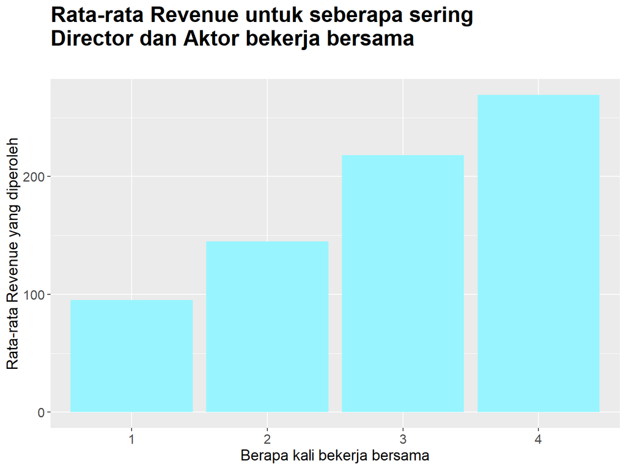

```r
#Untuk tiap kelompok (paling banyak sutradara dan aktor bekerja bersama sebanyak 4 kali)
counts <- c("1", "2", "3", "4")

#Hitung rata-rata revenue untuk tiap kategori
rev <- c(mean(dataActorDirector$MeanRev[dataActorDirector$CountFilm == 1], na.rm = TRUE), mean(dataActorDirector$MeanRev[dataActorDirector$CountFilm == 2], na.rm = TRUE), mean(dataActorDirector$MeanRev[dataActorDirector$CountFilm == 3], na.rm = TRUE), mean(dataActorDirector$MeanRev[dataActorDirector$CountFilm == 4], na.rm = TRUE))

#Buat dataframe baru untuk di buat plot
dataActor_5 <- data.frame(counts, rev)

ggplot(dataActor_5, aes(x = counts, y = rev))+
  geom_col(fill = 'cadetblue1')+
  ggtitle("Rata-rata Revenue untuk seberapa sering \nDirector dan Aktor bekerja bersama\n")+
  xlab("Berapa kali bekerja bersama")+
  ylab("Rata-rata Revenue yang diperoleh")+
  theme(axis.text=element_text(size=12), axis.title=element_text(size=14), plot.title = element_text(size = 20, face = "bold"))
```

# Insight dan Manfaat

Dari hasil analisis, kami mendapatkan insight sebagai berikut:

- Semakin sering seorang sutradara dan aktor bekerja bersama dalam suatu film, rata-rata pendapatannya juga akan semakin tinggi.

# Kesimpulan

Dari insight-insight yang kami dapatkan, keputusan bisnis yang dapat dilakukan:

- Dari analisis pertama dan kedua, didapat kesimpulan:
  - Bagi pihak produksi film, akan lebih menguntungkan dari segi pendapatan bila membuat film yang disutradarai dan dimainkan oleh sutradara dan aktor yang sudah sering bekerja bersama. Terutama bagi film-film yang merupakan serial atau lanjutan dari film sebelumnya. Begitu juga bagi sutradara lebih baik bila bekerja bersama lagi dengan aktor yang sebelumnya pernah bekerja bersama.